# Cars4U Project

### Key analysis objectives of the Project

1. Explore and visualize the dataset.
2. Build a linear regression model to predict the prices of used cars.
3. Generate a set of insights and recommendations that will help the business

### Data Context

The objective of the analysis is to come up with a pricing model that can effectively predict the price of used cars and can help the business in devising profitable strategies using differential pricing. Following details are available to come up with the model which can help achieve the business objectives.

1. S.No. : Serial Number
2. Name : Name of the car which includes Brand name and Model name
3. Location : The location in which the car is being sold or is available for purchase Cities
4. Year : Manufacturing year of the car
5. Kilometers_driven : The total kilometers driven in the car by the previous owner(s) in KM.
6. Fuel_Type : The type of fuel used by the car. (Petrol, Diesel, Electric, CNG, LPG)
7. Transmission : The type of transmission used by the car. (Automatic / Manual)
8. Owner : Type of ownership
9. Mileage : The standard mileage offered by the car company in kmpl or km/kg
10. Engine : The displacement volume of the engine in CC.
11. Power : The maximum power of the engine in bhp.
12. Seats : The number of seats in the car.
13. New_Price : The price of a new car of the same model in INR Lakhs.(1 Lakh = 100, 000)
14. Price : The price of the used car in INR Lakhs (1 Lakh = 100, 000)

#### Importing all the required packages for the project:

```python
import pandas as pd #importing Pandas for dataset import
import matplotlib.pyplot as plt #importing for basic visualization and seaborn
import seaborn as sns #importing for better visualization features
import warnings # importing to suppress the warnings of deprecated features
import numpy as np #importing numpy
warnings.filterwarnings('ignore') # suppress the warnings
#for inline plotting
%matplotlib inline
pd.set_option('display.float_format', lambda x: '%.5f' % x) #to suppress scientific notations
# Removes the limit for the number of displayed columns
pd.set_option("display.max_columns", None)
# Sets the limit for the number of displayed rows
pd.set_option("display.max_rows", 200)
# To build linear model for prediction
from sklearn.linear_model import LinearRegression
# To check model performance
from sklearn.metrics import mean_squared_error, r2_score, mean_absolute_error
import scipy.stats as stats
#for inline plotting
%matplotlib inline
pd.set_option('display.float_format', lambda x: '%.5f' % x) #to suppress scientific notations
```

#### Read in the dataset using pandas

```python
#importing dataset stored in csv file and setting 1st cloumn as index
df = pd.read_csv(r'C:\Users\user\Desktop\AI_ML_Austin\notebook prog files\ProjectWork2\used_cars_data.csv')
# creating a copy of the data so that original data remains unchanged
car4udf = df.copy()
```

#### To assess the data set (Top 10)

```python
car4udf.head(10) #display top 10 rows
```

|  | S.No. | Name | Location | Year | Kilometers_Driven | Fuel_Type | Transmission | Owner_Type | Mileage | Engine | Power | Seats | New_Price | Price |
| --- | --- | --- | --- | --- | --- | --- | --- | --- | --- | --- | --- | --- | --- | --- |
| 0 | 0 | Maruti Wagon R LXI CNG | Mumbai | 2010 | 72000 | CNG | Manual | First | 26.6 km/kg | 998 CC | 58.16 bhp | 5.00000 | NaN | 1.75000 |
| 1 | 1 | Hyundai Creta 1.6 CRDi SX Option | Pune | 2015 | 41000 | Diesel | Manual | First | 19.67 kmpl | 1582 CC | 126.2 bhp | 5.00000 | NaN | 12.50000 |
| 2 | 2 | Honda Jazz V | Chennai | 2011 | 46000 | Petrol | Manual | First | 18.2 kmpl | 1199 CC | 88.7 bhp | 5.00000 | 8.61 Lakh | 4.50000 |
| 3 | 3 | Maruti Ertiga VDI | Chennai | 2012 | 87000 | Diesel | Manual | First | 20.77 kmpl | 1248 CC | 88.76 bhp | 7.00000 | NaN | 6.00000 |
| 4 | 4 | Audi A4 New 2.0 TDI Multitronic | Coimbatore | 2013 | 40670 | Diesel | Automatic | Second | 15.2 kmpl | 1968 CC | 140.8 bhp | 5.00000 | NaN | 17.74000 |
| 5 | 5 | Hyundai EON LPG Era Plus Option | Hyderabad | 2012 | 75000 | LPG | Manual | First | 21.1 km/kg | 814 CC | 55.2 bhp | 5.00000 | NaN | 2.35000 |
| 6 | 6 | Nissan Micra Diesel XV | Jaipur | 2013 | 86999 | Diesel | Manual | First | 23.08 kmpl | 1461 CC | 63.1 bhp | 5.00000 | NaN | 3.50000 |
| 7 | 7 | Toyota Innova Crysta 2.8 GX AT 8S | Mumbai | 2016 | 36000 | Diesel | Automatic | First | 11.36 kmpl | 2755 CC | 171.5 bhp | 8.00000 | 21 Lakh | 17.50000 |
| 8 | 8 | Volkswagen Vento Diesel Comfortline | Pune | 2013 | 64430 | Diesel | Manual | First | 20.54 kmpl | 1598 CC | 103.6 bhp | 5.00000 | NaN | 5.20000 |
| 9 | 9 | Tata Indica Vista Quadrajet LS | Chennai | 2012 | 65932 | Diesel | Manual | Second | 22.3 kmpl | 1248 CC | 74 bhp | 5.00000 | NaN | 1.95000 |

Its always better to check the random rows instead of top rows.

```python
np.random.seed(1) #random set with seed 1, so the same set of random values can be generated everytime
car4udf.sample(n=20) #Print 20 random rows to check the dataset
```

|  | S.No. | Name | Location | Year | Kilometers_Driven | Fuel_Type | Transmission | Owner_Type | Mileage | Engine | Power | Seats | New_Price | Price |
| --- | --- | --- | --- | --- | --- | --- | --- | --- | --- | --- | --- | --- | --- | --- |
| 2397 | 2397 | Ford EcoSport 1.5 Petrol Trend | Kolkata | 2016 | 21460 | Petrol | Manual | First | 17.0 kmpl | 1497 CC | 121.36 bhp | 5.00000 | 9.47 Lakh | 6.00000 |
| 3777 | 3777 | Maruti Wagon R VXI 1.2 | Kochi | 2015 | 49818 | Petrol | Manual | First | 21.5 kmpl | 1197 CC | 81.80 bhp | 5.00000 | 5.44 Lakh | 4.11000 |
| 4425 | 4425 | Ford Endeavour 4x2 XLT | Hyderabad | 2007 | 130000 | Diesel | Manual | First | 13.1 kmpl | 2499 CC | 141 bhp | 7.00000 | NaN | 6.00000 |
| 3661 | 3661 | Mercedes-Benz E-Class E250 CDI Avantgrade | Coimbatore | 2016 | 39753 | Diesel | Automatic | First | 13.0 kmpl | 2143 CC | 201.1 bhp | 5.00000 | NaN | 35.28000 |
| 4514 | 4514 | Hyundai Xcent 1.2 Kappa AT SX Option | Kochi | 2016 | 45560 | Petrol | Automatic | First | 16.9 kmpl | 1197 CC | 82 bhp | 5.00000 | NaN | 6.34000 |
| 599 | 599 | Toyota Innova Crysta 2.8 ZX AT | Coimbatore | 2019 | 40674 | Diesel | Automatic | First | 11.36 kmpl | 2755 CC | 171.5 bhp | 7.00000 | 28.05 Lakh | 24.82000 |
| 186 | 186 | Mercedes-Benz E-Class E250 CDI Avantgrade | Bangalore | 2014 | 37382 | Diesel | Automatic | First | 13.0 kmpl | 2143 CC | 201.1 bhp | 5.00000 | NaN | 32.00000 |
| 305 | 305 | Audi A6 2011-2015 2.0 TDI Premium Plus | Kochi | 2014 | 61726 | Diesel | Automatic | First | 17.68 kmpl | 1968 CC | 174.33 bhp | 5.00000 | NaN | 20.77000 |
| 4582 | 4582 | Hyundai i20 1.2 Magna | Kolkata | 2011 | 36000 | Petrol | Manual | First | 18.5 kmpl | 1197 CC | 80 bhp | 5.00000 | NaN | 2.50000 |
| 5434 | 5434 | Honda WR-V Edge Edition i-VTEC S | Kochi | 2019 | 13913 | Petrol | Manual | First | 17.5 kmpl | 1199 CC | 88.7 bhp | 5.00000 | 9.36 Lakh | 8.20000 |
| 3042 | 3042 | Hyundai Verna 1.6 VTVT | Kolkata | 2011 | 36226 | Petrol | Manual | First | 17.01 kmpl | 1591 CC | 121.3 bhp | 5.00000 | NaN | 2.95000 |
| 503 | 503 | Toyota Fortuner 4x4 AT | Delhi | 2017 | 25000 | Diesel | Automatic | First | 12.55 kmpl | 2982 CC | 168.5 bhp | 7.00000 | NaN | 32.00000 |
| 1038 | 1038 | Land Rover Range Rover TDV8 (Diesel) | Bangalore | 2011 | 55000 | Diesel | Automatic | First | 10.2 kmpl | 4367 CC | 308 bhp | 7.00000 | NaN | 67.00000 |
| 4543 | 4543 | Maruti Alto K10 VXI AGS | Chennai | 2017 | 5500 | Petrol | Automatic | First | 24.07 kmpl | 998 CC | 67.1 bhp | 5.00000 | NaN | 4.25000 |
| 2328 | 2328 | BMW X5 xDrive 30d M Sport | Chennai | 2017 | 6500000 | Diesel | Automatic | First | 15.97 kmpl | 2993 CC | 258 bhp | 5.00000 | NaN | 65.00000 |
| 343 | 343 | Maruti Vitara Brezza LDi | Chennai | 2016 | 45000 | Diesel | Manual | First | 24.3 kmpl | 1248 CC | 88.5 bhp | 5.00000 | 9.12 Lakh | 7.15000 |
| 4172 | 4172 | Maruti Swift Dzire LXI | Delhi | 2014 | 56510 | Petrol | Manual | First | 19.1 kmpl | 1197 CC | 85.8 bhp | 5.00000 | NaN | 3.90000 |
| 5213 | 5213 | Toyota Innova 2.5 VX (Diesel) 8 Seater BS IV | Pune | 2015 | 77000 | Diesel | Manual | First | 12.99 kmpl | 2494 CC | 100 bhp | 8.00000 | NaN | 12.50000 |
| 3353 | 3353 | Hyundai Xcent 1.2 Kappa AT SX Option | Chennai | 2015 | 59800 | Petrol | Automatic | First | 16.9 kmpl | 1197 CC | 82 bhp | 5.00000 | NaN | 5.80000 |
| 2982 | 2982 | Hyundai Creta 1.6 SX Plus Petrol Automatic | Coimbatore | 2018 | 32807 | Petrol | Automatic | First | 13.0 kmpl | 1591 CC | 121.3 bhp | 5.00000 | NaN | 14.76000 |

The dataset looks consistent with the description provided in the Data Dictionary. Lots of data have values which need to be processed so the data can be effectively used for analysis

#### Check the shape of the provided data

```python
print(f'There are {car4udf.shape[0]} rows and {car4udf.shape[1]} columns.')  # f-string
```

```
There are 7253 rows and 14 columns.
```

There are 7253 rows/observations of 14 columns

#### Check datatype count

```python
car4udf.dtypes.value_counts() #Gives count of the different datatype in dataset
```

```
object     9
int64      3
float64    2
dtype: int64
```

#### Get the complete info of the dataset

```python
car4udf.info() #display complete info
```

```
<class 'pandas.core.frame.DataFrame'>
RangeIndex: 7253 entries, 0 to 7252
Data columns (total 14 columns):
 #   Column             Non-Null Count  Dtype
---  ------             --------------  -----
 0   S.No.              7253 non-null   int64
 1   Name               7253 non-null   object
 2   Location           7253 non-null   object
 3   Year               7253 non-null   int64
 4   Kilometers_Driven  7253 non-null   int64
 5   Fuel_Type          7253 non-null   object
 6   Transmission       7253 non-null   object
 7   Owner_Type         7253 non-null   object
 8   Mileage            7251 non-null   object
 9   Engine             7207 non-null   object
 10  Power              7207 non-null   object
 11  Seats              7200 non-null   float64
 12  New_Price          1006 non-null   object
 13  Price              6019 non-null   float64
dtypes: float64(2), int64(3), object(9)
memory usage: 793.4+ KB
```

#### Describe all columns

```python
car4udf.describe(include="all").T #describe all dataset. Use transpose so column wise details can be view from top to bottom
```

|  | count | unique | top | freq | mean | std | min | 25% | 50% | 75% | max |
| --- | --- | --- | --- | --- | --- | --- | --- | --- | --- | --- | --- |
| S.No. | 7253.00000 | NaN | NaN | NaN | 3626.00000 | 2093.90508 | 0.00000 | 1813.00000 | 3626.00000 | 5439.00000 | 7252.00000 |
| Name | 7253 | 2041 | Mahindra XUV500 W8 2WD | 55 | NaN | NaN | NaN | NaN | NaN | NaN | NaN |
| Location | 7253 | 11 | Mumbai | 949 | NaN | NaN | NaN | NaN | NaN | NaN | NaN |
| Year | 7253.00000 | NaN | NaN | NaN | 2013.36537 | 3.25442 | 1996.00000 | 2011.00000 | 2014.00000 | 2016.00000 | 2019.00000 |
| Kilometers_Driven | 7253.00000 | NaN | NaN | NaN | 58699.06315 | 84427.72058 | 171.00000 | 34000.00000 | 53416.00000 | 73000.00000 | 6500000.00000 |
| Fuel_Type | 7253 | 5 | Diesel | 3852 | NaN | NaN | NaN | NaN | NaN | NaN | NaN |
| Transmission | 7253 | 2 | Manual | 5204 | NaN | NaN | NaN | NaN | NaN | NaN | NaN |
| Owner_Type | 7253 | 4 | First | 5952 | NaN | NaN | NaN | NaN | NaN | NaN | NaN |
| Mileage | 7251 | 450 | 17.0 kmpl | 207 | NaN | NaN | NaN | NaN | NaN | NaN | NaN |
| Engine | 7207 | 150 | 1197 CC | 732 | NaN | NaN | NaN | NaN | NaN | NaN | NaN |
| Power | 7207 | 386 | 74 bhp | 280 | NaN | NaN | NaN | NaN | NaN | NaN | NaN |
| Seats | 7200.00000 | NaN | NaN | NaN | 5.27972 | 0.81166 | 0.00000 | 5.00000 | 5.00000 | 5.00000 | 10.00000 |
| New_Price | 1006 | 625 | 4.78 Lakh | 6 | NaN | NaN | NaN | NaN | NaN | NaN | NaN |
| Price | 6019.00000 | NaN | NaN | NaN | 9.47947 | 11.18792 | 0.44000 | 3.50000 | 5.64000 | 9.95000 | 160.00000 |

### Data Analysis:

Car and its sales profile based on the data set:

1. S.No Range is from 0 to 7252 and there are no missing values
2. Total unique cars names are 2041 and there are no missing values
3. Total unique locations of sales are 11 and no value is missing
4. Car sales data available in dataset are from year 1996 to 2019.There are no missing values
5. Kilometer driven is available for all rows
6. There 5 unique fuel type and there are no null values. More than 50% of vehicles listed are Diesel type
7. There are two unique transmission type and values for all the rows are available. There are far more manual transmission vehicles.
8. There are 4 unique Owner type and highest being the first. No missing values.
9. Mileage , Engine type, Power, seats, New price and Price columns have many missing values
10. There is a correlation between missing values of Engine and Power.
11. Some cars have 0 number of seats which appears inconsistent, unless we also have driver and passenger less self driving cars in the list. (As the data is from India and such cars are not allowed in open market as per regulation hence this inconsistency need to be addressed)
12. These are no columns which need to be dropped at this stage of analysis. All the columns in data frame appears useful for further analysis.
13. For getting additional details further processing of data need to carried out.

#### Checking % of missing values

```python
def missingvaluecheck(dat): #function to find missing values within the dataset
    calc_total = dat.isnull().sum().sort_values(ascending=False) #Checking for total null values
    calc_percent = (dat.isnull().sum()/dat.isnull().count()).sort_values(ascending=False) #checking percentage
    data_missing = pd.concat([calc_total, calc_percent], axis=1, keys=['Total', '% of Missing Val']) #to display missing data count and percentage
    return data_missing # return the dataframe
missingvaluecheck(car4udf) #calling the function
```

|  | Total | % of Missing Val |
| --- | --- | --- |
| New_Price | 6247 | 0.86130 |
| Price | 1234 | 0.17014 |
| Seats | 53 | 0.00731 |
| Power | 46 | 0.00634 |
| Engine | 46 | 0.00634 |
| Mileage | 2 | 0.00028 |
| Owner_Type | 0 | 0.00000 |
| Transmission | 0 | 0.00000 |
| Fuel_Type | 0 | 0.00000 |
| Kilometers_Driven | 0 | 0.00000 |
| Year | 0 | 0.00000 |
| Location | 0 | 0.00000 |
| Name | 0 | 0.00000 |
| S.No. | 0 | 0.00000 |

There are missing values present which need to be considered during the analysis. There is pattern to the missingess for Engine type and power. The power of engine is dependent of engine hence both are missing. Need to check if the values are missing for same rows or are missing for different rows without any pattern.

## Data Processing Part 1

Objective is basic streamlining and cleansing of data

Identify the values which can be converted to numeric by removing the prefix of suffix characters.

```python
car4udf_dum = car4udf.copy()
iden_prefix_cols=['Mileage', 'Engine', 'Power', 'New_Price']
all_pre_suf=[]
all_pre_suf_uni=[]
def print_suf_pre(str_val):
        if isinstance (str_val,str): #check id the value is string type
            spl_val=str_val.split(" ") #split the string value based on single space (Not to be used without checking if numeric data have embedded space)
            if spl_val[1]:
                all_pre_suf.append(spl_val[1])
                all_pre_suf_uni=set(all_pre_suf)
            #return (print(all_pre_suf_uni))

for colname in iden_prefix_cols: #apply the function for all the colums identified and saved in last step
    car4udf_dum[colname] = car4udf_dum[colname].apply(print_suf_pre)
```

Output: {'CC', 'Cr', 'bhp', 'kmpl', 'Lakh', 'km/kg'}

```python
#This will print list of all columns which have the suffixes
iden_prefix_cols=[] #list for saming prefixes
for colname in car4udf.columns[car4udf.dtypes=='object']: #loop each column in data frame
    suffixes =('CC', 'kmpl', 'Cr', 'Lakh', 'km/kg', 'bhp') #specify the list of suffixes that need to be checked
    if car4udf[colname].str.endswith(suffixes).any(): #condition to check if the values in columns end with any of the given suffixes
        iden_prefix_cols.append(colname) #all the columns meeting the conditions added to the list
print(iden_prefix_cols) #print the final list
```

```
['Mileage', 'Engine', 'Power', 'New_Price']
```

Identified columns for preprocessing are Mileage (kmpl),Engine (CC),Power(bhp) and New_Price(Lakh) After identifying the columns with the identified suffix we need to do preprocessing

{'CC', 'kmpl', 'Cr', 'Lakh', 'km/kg', 'bhp'}

CC: Need to be removed to make value numeric Kmpl: Need to be removed to make value numeric Cr: Need to be converted for Lakh Km/kg: Need to be removed to make value numeric bhp:Need to be removed to make value numeric

#### Change Cr to Lakh and removed the string part of the variables

```python
def cr_to_lakh(var):
    if isinstance(var, str):  # checking if the value is string or not
        if "Cr" in var:  # checking for the presence of Cr
            spl = var.split(" ")  # splitting the value by space
            new_val = (
                float(spl[0].replace("Cr", "")) * 100
            )  # taking numeric part and converting to lakh
            return new_val
        else:
            return float(var.replace("Lakh", ""))  # taking numeric part of Lakh
    else:
        return np.nan  # will return NaN if value is not string
```

```python
car4udf['New_Price'] = car4udf['New_Price'].apply(cr_to_lakh)
car4udf.head(5)
```

|  | S.No. | Name | Location | Year | Kilometers_Driven | Fuel_Type | Transmission | Owner_Type | Mileage | Engine | Power | Seats | New_Price | Price |
| --- | --- | --- | --- | --- | --- | --- | --- | --- | --- | --- | --- | --- | --- | --- |
| 0 | 0 | Maruti Wagon R LXI CNG | Mumbai | 2010 | 72000 | CNG | Manual | First | 26.6 km/kg | 998 CC | 58.16 bhp | 5.00000 | nan | 1.75000 |
| 1 | 1 | Hyundai Creta 1.6 CRDi SX Option | Pune | 2015 | 41000 | Diesel | Manual | First | 19.67 kmpl | 1582 CC | 126.2 bhp | 5.00000 | nan | 12.50000 |
| 2 | 2 | Honda Jazz V | Chennai | 2011 | 46000 | Petrol | Manual | First | 18.2 kmpl | 1199 CC | 88.7 bhp | 5.00000 | 8.61000 | 4.50000 |
| 3 | 3 | Maruti Ertiga VDI | Chennai | 2012 | 87000 | Diesel | Manual | First | 20.77 kmpl | 1248 CC | 88.76 bhp | 7.00000 | nan | 6.00000 |
| 4 | 4 | Audi A4 New 2.0 TDI Multitronic | Coimbatore | 2013 | 40670 | Diesel | Automatic | Second | 15.2 kmpl | 1968 CC | 140.8 bhp | 5.00000 | nan | 17.74000 |

#### Remove 'CC', 'kmpl', 'km/kg', 'bhp' from remaining columns

```python
#### function to remove the suffixes from the columns
#Alert: This function will remove any suffix without considering the values of suffix
def remove_given_prefix_cols(str_val):
    if isinstance (str_val,str): #check id the value is string type
        spl_val=str_val.split(" ") #split the string value based on single space (Not to be used without checking if numeric data have embedded space)
        if spl_val[0] == "null":   #to handle null string saved in the Power column
            return float(0)
        else:
            return float(spl_val[0])
    else:
        return np.nan

car4udf['Mileage'] = car4udf['Mileage'].apply(remove_given_prefix_cols) #removing prefix
car4udf['Engine'] = car4udf['Engine'].apply(remove_given_prefix_cols) #removing prefix
car4udf['Power'] = car4udf['Power'].apply(remove_given_prefix_cols) #removing prefix
```

```python
car4udf.head(5) #validate
```

|  | S.No. | Name | Location | Year | Kilometers_Driven | Fuel_Type | Transmission | Owner_Type | Mileage | Engine | Power | Seats | New_Price | Price |
| --- | --- | --- | --- | --- | --- | --- | --- | --- | --- | --- | --- | --- | --- | --- |
| 0 | 0 | Maruti Wagon R LXI CNG | Mumbai | 2010 | 72000 | CNG | Manual | First | 26.60000 | 998.00000 | 58.16000 | 5.00000 | nan | 1.75000 |
| 1 | 1 | Hyundai Creta 1.6 CRDi SX Option | Pune | 2015 | 41000 | Diesel | Manual | First | 19.67000 | 1582.00000 | 126.20000 | 5.00000 | nan | 12.50000 |
| 2 | 2 | Honda Jazz V | Chennai | 2011 | 46000 | Petrol | Manual | First | 18.20000 | 1199.00000 | 88.70000 | 5.00000 | 8.61000 | 4.50000 |
| 3 | 3 | Maruti Ertiga VDI | Chennai | 2012 | 87000 | Diesel | Manual | First | 20.77000 | 1248.00000 | 88.76000 | 7.00000 | nan | 6.00000 |
| 4 | 4 | Audi A4 New 2.0 TDI Multitronic | Coimbatore | 2013 | 40670 | Diesel | Automatic | Second | 15.20000 | 1968.00000 | 140.80000 | 5.00000 | nan | 17.74000 |

```python
car4udf.info() #validate
```

```
<class 'pandas.core.frame.DataFrame'>
RangeIndex: 7253 entries, 0 to 7252
Data columns (total 14 columns):
 #   Column             Non-Null Count  Dtype
---  ------             --------------  -----
 0   S.No.              7253 non-null   int64
 1   Name               7253 non-null   object
 2   Location           7253 non-null   object
 3   Year               7253 non-null   int64
 4   Kilometers_Driven  7253 non-null   int64
 5   Fuel_Type          7253 non-null   object
 6   Transmission       7253 non-null   object
 7   Owner_Type         7253 non-null   object
 8   Mileage            7251 non-null   float64
 9   Engine             7207 non-null   float64
 10  Power              7207 non-null   float64
 11  Seats              7200 non-null   float64
 12  New_Price          1006 non-null   float64
 13  Price              6019 non-null   float64
dtypes: float64(6), int64(3), object(5)
memory usage: 793.4+ KB
```

```python
car4udf.head(10) #check the outcome of the data processing
```

|  | S.No. | Name | Location | Year | Kilometers_Driven | Fuel_Type | Transmission | Owner_Type | Mileage | Engine | Power | Seats | New_Price | Price |
| --- | --- | --- | --- | --- | --- | --- | --- | --- | --- | --- | --- | --- | --- | --- |
| 0 | 0 | Maruti Wagon R LXI CNG | Mumbai | 2010 | 72000 | CNG | Manual | First | 26.60000 | 998.00000 | 58.16000 | 5.00000 | nan | 1.75000 |
| 1 | 1 | Hyundai Creta 1.6 CRDi SX Option | Pune | 2015 | 41000 | Diesel | Manual | First | 19.67000 | 1582.00000 | 126.20000 | 5.00000 | nan | 12.50000 |
| 2 | 2 | Honda Jazz V | Chennai | 2011 | 46000 | Petrol | Manual | First | 18.20000 | 1199.00000 | 88.70000 | 5.00000 | 8.61000 | 4.50000 |
| 3 | 3 | Maruti Ertiga VDI | Chennai | 2012 | 87000 | Diesel | Manual | First | 20.77000 | 1248.00000 | 88.76000 | 7.00000 | nan | 6.00000 |
| 4 | 4 | Audi A4 New 2.0 TDI Multitronic | Coimbatore | 2013 | 40670 | Diesel | Automatic | Second | 15.20000 | 1968.00000 | 140.80000 | 5.00000 | nan | 17.74000 |
| 5 | 5 | Hyundai EON LPG Era Plus Option | Hyderabad | 2012 | 75000 | LPG | Manual | First | 21.10000 | 814.00000 | 55.20000 | 5.00000 | nan | 2.35000 |
| 6 | 6 | Nissan Micra Diesel XV | Jaipur | 2013 | 86999 | Diesel | Manual | First | 23.08000 | 1461.00000 | 63.10000 | 5.00000 | nan | 3.50000 |
| 7 | 7 | Toyota Innova Crysta 2.8 GX AT 8S | Mumbai | 2016 | 36000 | Diesel | Automatic | First | 11.36000 | 2755.00000 | 171.50000 | 8.00000 | 21.00000 | 17.50000 |
| 8 | 8 | Volkswagen Vento Diesel Comfortline | Pune | 2013 | 64430 | Diesel | Manual | First | 20.54000 | 1598.00000 | 103.60000 | 5.00000 | nan | 5.20000 |
| 9 | 9 | Tata Indica Vista Quadrajet LS | Chennai | 2012 | 65932 | Diesel | Manual | Second | 22.30000 | 1248.00000 | 74.00000 | 5.00000 | nan | 1.95000 |

```python
car4udf.info() #to check the coversion to float
```

```
<class 'pandas.core.frame.DataFrame'>
RangeIndex: 7253 entries, 0 to 7252
Data columns (total 14 columns):
 #   Column             Non-Null Count  Dtype
---  ------             --------------  -----
 0   S.No.              7253 non-null   int64
 1   Name               7253 non-null   object
 2   Location           7253 non-null   object
 3   Year               7253 non-null   int64
 4   Kilometers_Driven  7253 non-null   int64
 5   Fuel_Type          7253 non-null   object
 6   Transmission       7253 non-null   object
 7   Owner_Type         7253 non-null   object
 8   Mileage            7251 non-null   float64
 9   Engine             7207 non-null   float64
 10  Power              7207 non-null   float64
 11  Seats              7200 non-null   float64
 12  New_Price          1006 non-null   float64
 13  Price              6019 non-null   float64
dtypes: float64(6), int64(3), object(5)
memory usage: 793.4+ KB
```

Now the Mileage, Engine, Power and New Price has been converted to Float

Check zero values for the converted columns

```python
print('Power',car4udf.query("Power == '0.0'")['Power'].count()) #print the count of 0 Value
print('Mileage',car4udf.query("Mileage == '0.0'")['Mileage'].count()) #print the count of 0 Value
print('New_Price',car4udf.query("New_Price == '0.0'")['New_Price'].count()) #print the count of 0 Value
print('Price', car4udf.query("Price == '0.0'")['Price'].count()) #print the count of 0 Value
```

```
Power 129
Mileage 81
New_Price 0
Price 0
```

As these values cant be zero and can lead to wrong interpretation of data during the analysis, they should be converted to Nan

```python
car4udf['Power'].replace(0.0, np.nan, inplace= True) #replaced by null
car4udf['Mileage'].replace(0.0, np.nan, inplace= True) #replaced by null
```

```python
print('Power',car4udf.query("Power == '0.0'")['Power'].count()) #print the count of 0 Value
print('Mileage',car4udf.query("Mileage == '0.0'")['Mileage'].count()) #print the count of 0 Value
print('New_Price',car4udf.query("New_Price == '0.0'")['New_Price'].count()) #print the count of 0 Value
print('Price', car4udf.query("Price == '0.0'")['Price'].count()) #print the count of 0 Value
```

```
Power 0
Mileage 0
New_Price 0
Price 0
```

Required changes have been done

#### Now process the remaining object type column

```python
num_to_display = 15  # defining this up here so it's easy to change later if I want
for colname in car4udf.dtypes[car4udf.dtypes == 'object'].index:
    val_counts = car4udf[colname].value_counts(dropna=False)  # i want to see NA counts
    print(val_counts[:num_to_display])
    if len(val_counts) > num_to_display:
        print(f'Only displaying first {num_to_display} of {len(val_counts)} values.')
    print('\n\n') # just for more space between
```

```
Mahindra XUV500 W8 2WD        55
Maruti Swift VDI              49
Maruti Swift Dzire VDI        42
Honda City 1.5 S MT           39
Maruti Swift VDI BSIV         37
Maruti Ritz VDi               35
Toyota Fortuner 3.0 Diesel    35
Hyundai Grand i10 Sportz      32
Honda Amaze S i-Dtech         32
Honda Brio S MT               32
Honda City 1.5 V MT           32
Hyundai i10 Sportz            31
Maruti Alto LXi               30
Maruti Wagon R LXI            29
Maruti Ertiga VDI             28
Name: Name, dtype: int64
Only displaying first 15 of 2041 values.



Mumbai        949
Hyderabad     876
Kochi         772
Coimbatore    772
Pune          765
Delhi         660
Kolkata       654
Chennai       591
Jaipur        499
Bangalore     440
Ahmedabad     275
Name: Location, dtype: int64



Diesel      3852
Petrol      3325
CNG           62
LPG           12
Electric       2
Name: Fuel_Type, dtype: int64



Manual       5204
Automatic    2049
Name: Transmission, dtype: int64



First             5952
Second            1152
Third              137
Fourth & Above      12
Name: Owner_Type, dtype: int64
```

Car_Company name can be a useful information and can be extracted form car name. As the first word is the company name, we can use the existing function

```python
def company_name(str_val):
    if isinstance (str_val,str): #check id the value is string type
        spl_val=str_val.split(" ") #split the string value based on single space (Not to be used without checking if numeric data have embedded space)
        if spl_val[0] == "null":   #to handle null string saved in the Power column
            return np.nan
        else:
            return spl_val[0]
    else:
        return np.nan
# create a copy of our dataframe for further processing
car4udf2 = car4udf.copy()
car4udf2['Name'] = car4udf2['Name'].apply(company_name) # function call for name
car4udf2.head(20)
```

|  | S.No. | Name | Location | Year | Kilometers_Driven | Fuel_Type | Transmission | Owner_Type | Mileage | Engine | Power | Seats | New_Price | Price |
| --- | --- | --- | --- | --- | --- | --- | --- | --- | --- | --- | --- | --- | --- | --- |
| 0 | 0 | Maruti | Mumbai | 2010 | 72000 | CNG | Manual | First | 26.60000 | 998.00000 | 58.16000 | 5.00000 | nan | 1.75000 |
| 1 | 1 | Hyundai | Pune | 2015 | 41000 | Diesel | Manual | First | 19.67000 | 1582.00000 | 126.20000 | 5.00000 | nan | 12.50000 |
| 2 | 2 | Honda | Chennai | 2011 | 46000 | Petrol | Manual | First | 18.20000 | 1199.00000 | 88.70000 | 5.00000 | 8.61000 | 4.50000 |
| 3 | 3 | Maruti | Chennai | 2012 | 87000 | Diesel | Manual | First | 20.77000 | 1248.00000 | 88.76000 | 7.00000 | nan | 6.00000 |
| 4 | 4 | Audi | Coimbatore | 2013 | 40670 | Diesel | Automatic | Second | 15.20000 | 1968.00000 | 140.80000 | 5.00000 | nan | 17.74000 |
| 5 | 5 | Hyundai | Hyderabad | 2012 | 75000 | LPG | Manual | First | 21.10000 | 814.00000 | 55.20000 | 5.00000 | nan | 2.35000 |
| 6 | 6 | Nissan | Jaipur | 2013 | 86999 | Diesel | Manual | First | 23.08000 | 1461.00000 | 63.10000 | 5.00000 | nan | 3.50000 |
| 7 | 7 | Toyota | Mumbai | 2016 | 36000 | Diesel | Automatic | First | 11.36000 | 2755.00000 | 171.50000 | 8.00000 | 21.00000 | 17.50000 |
| 8 | 8 | Volkswagen | Pune | 2013 | 64430 | Diesel | Manual | First | 20.54000 | 1598.00000 | 103.60000 | 5.00000 | nan | 5.20000 |
| 9 | 9 | Tata | Chennai | 2012 | 65932 | Diesel | Manual | Second | 22.30000 | 1248.00000 | 74.00000 | 5.00000 | nan | 1.95000 |
| 10 | 10 | Maruti | Kochi | 2018 | 25692 | Petrol | Manual | First | 21.56000 | 1462.00000 | 103.25000 | 5.00000 | 10.65000 | 9.95000 |
| 11 | 11 | Honda | Kolkata | 2012 | 60000 | Petrol | Automatic | First | 16.80000 | 1497.00000 | 116.30000 | 5.00000 | nan | 4.49000 |
| 12 | 12 | Maruti | Jaipur | 2015 | 64424 | Diesel | Manual | First | 25.20000 | 1248.00000 | 74.00000 | 5.00000 | nan | 5.60000 |
| 13 | 13 | Land | Delhi | 2014 | 72000 | Diesel | Automatic | First | 12.70000 | 2179.00000 | 187.70000 | 5.00000 | nan | 27.00000 |
| 14 | 14 | Land | Pune | 2012 | 85000 | Diesel | Automatic | Second | nan | 2179.00000 | 115.00000 | 5.00000 | nan | 17.50000 |
| 15 | 15 | Mitsubishi | Delhi | 2014 | 110000 | Diesel | Manual | First | 13.50000 | 2477.00000 | 175.56000 | 7.00000 | 32.01000 | 15.00000 |
| 16 | 16 | Honda | Kochi | 2016 | 58950 | Diesel | Manual | First | 25.80000 | 1498.00000 | 98.60000 | 5.00000 | nan | 5.40000 |
| 17 | 17 | Maruti | Jaipur | 2017 | 25000 | Diesel | Manual | First | 28.40000 | 1248.00000 | 74.00000 | 5.00000 | nan | 5.99000 |
| 18 | 18 | Renault | Kochi | 2014 | 77469 | Diesel | Manual | First | 20.45000 | 1461.00000 | 83.80000 | 5.00000 | nan | 6.34000 |
| 19 | 19 | Mercedes-Benz | Bangalore | 2014 | 78500 | Diesel | Automatic | First | 14.84000 | 2143.00000 | 167.62000 | 5.00000 | nan | 28.00000 |

Change the categorical columns like Location, Fuel_Type, Transmission and Owner_Type to numeric values

## Data Analysis: Univariate Analysis

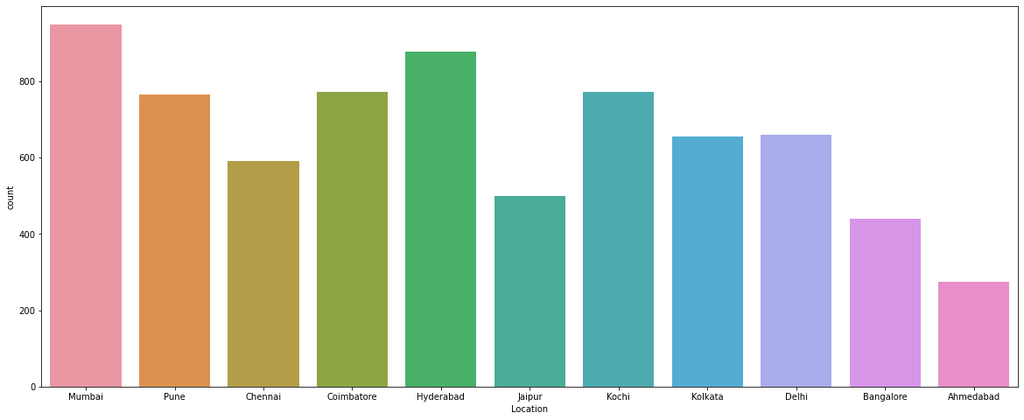

```python
plt.figure(figsize=(20,8))
sns.countplot(car4udf2['Location']);
```

Top five cities in terms of sales are Mumbai, Hyderabad, Pune, Coimbatore and Kochi Distribution appears normal

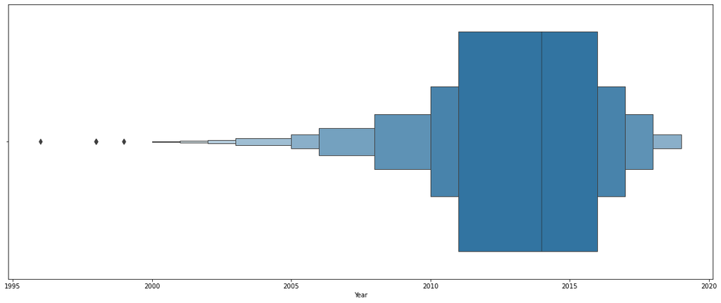

```python
plt.figure(figsize=(20,8))
sns.boxenplot(x=car4udf2["Year"]); #using  box-and-whisker plot
```

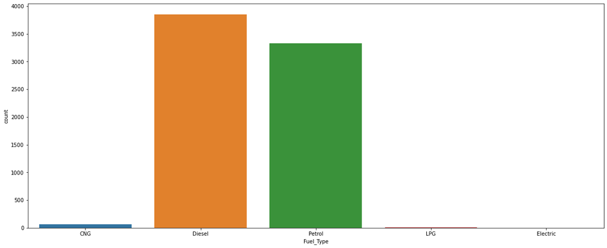

```python
plt.figure(figsize=(20,8))
sns.countplot(car4udf2['Fuel_Type']);
```

Most popular fuel type is Diesel.

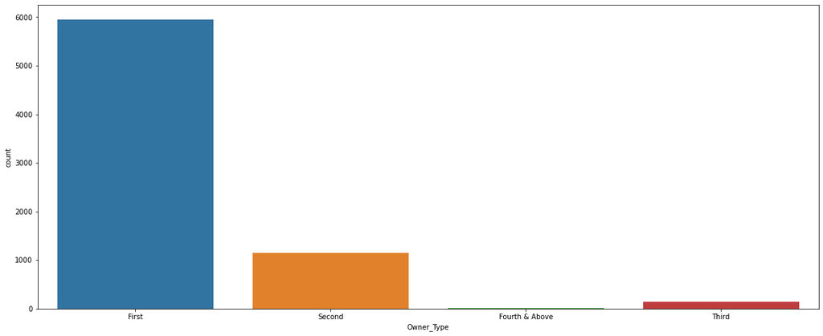

```python
plt.figure(figsize=(20,8))
sns.countplot(car4udf2['Owner_Type']);
```

First resale cars are most popular

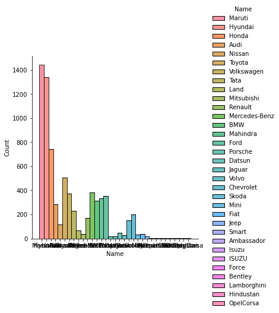

```python
sns.displot(car4udf2, x="Name", hue="Name", multiple="stack"); #use of stack for Companies
```

Maruti and Hyundai highest selling cars. Other big players are Honda and Toyota

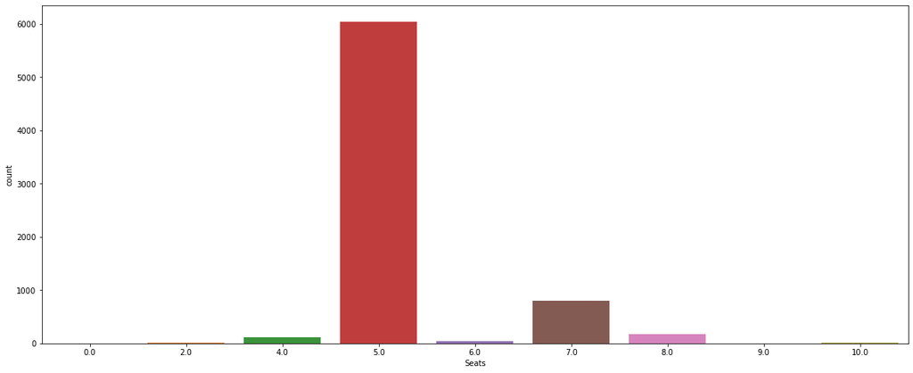

```python
plt.figure(figsize=(20,8))
sns.countplot(car4udf2['Seats']);
```

Five seater cars are most popular

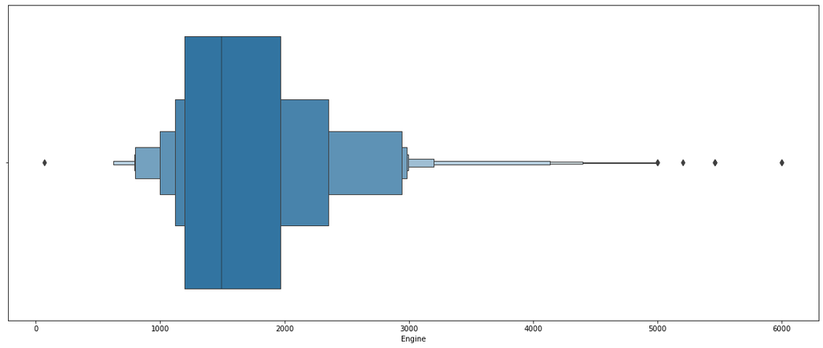

```python
plt.figure(figsize=(20,8))
sns.boxenplot(x=car4udf2["Engine"]); #using  box-and-whisker plot
```

Most popular engine type ranges between 1200 cc and less than 2000 cc Engine is right skewed

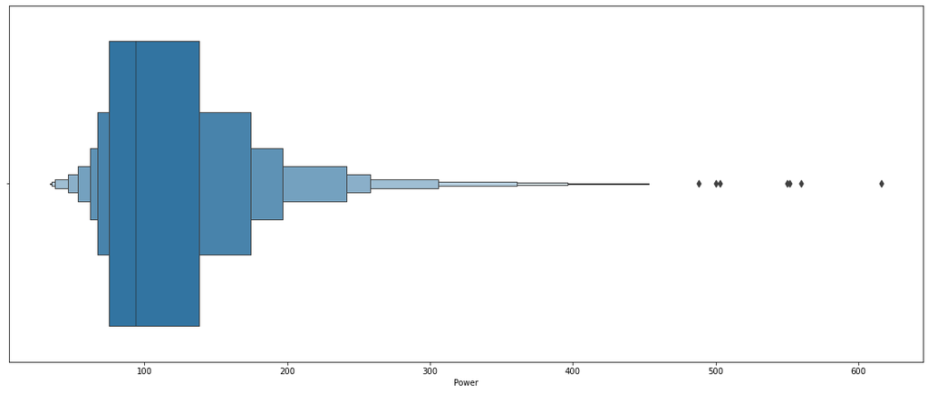

```python
plt.figure(figsize=(20,8))
sns.boxenplot(x=car4udf2["Power"]); #using  box-and-whisker plot
```

Most popular power of engine ranges between 75 bhp and 130 bhp Power is right skewed

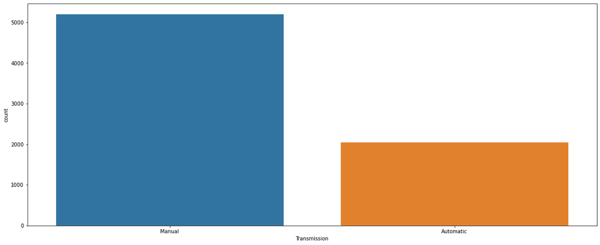

```python
plt.figure(figsize=(20,8))
sns.countplot(car4udf2['Transmission']);
```

Manual transmission is more popular that Automatic

## Data Processing Part 2

Objective is to change the dataframe to numeric dataframe so the modeling can be used effectively.

```python
car4udf2['Transmission'] = car4udf2['Transmission'].astype('category').cat.codes #changing the categorical value to codes
car4udf2.head(20)
```

|  | S.No. | Name | Location | Year | Kilometers_Driven | Fuel_Type | Transmission | Owner_Type | Mileage | Engine | Power | Seats | New_Price | Price |
| --- | --- | --- | --- | --- | --- | --- | --- | --- | --- | --- | --- | --- | --- | --- |
| 0 | 0 | Maruti | Mumbai | 2010 | 72000 | CNG | 1 | First | 26.60000 | 998.00000 | 58.16000 | 5.00000 | nan | 1.75000 |
| 1 | 1 | Hyundai | Pune | 2015 | 41000 | Diesel | 1 | First | 19.67000 | 1582.00000 | 126.20000 | 5.00000 | nan | 12.50000 |
| 2 | 2 | Honda | Chennai | 2011 | 46000 | Petrol | 1 | First | 18.20000 | 1199.00000 | 88.70000 | 5.00000 | 8.61000 | 4.50000 |
| 3 | 3 | Maruti | Chennai | 2012 | 87000 | Diesel | 1 | First | 20.77000 | 1248.00000 | 88.76000 | 7.00000 | nan | 6.00000 |
| 4 | 4 | Audi | Coimbatore | 2013 | 40670 | Diesel | 0 | Second | 15.20000 | 1968.00000 | 140.80000 | 5.00000 | nan | 17.74000 |
| 5 | 5 | Hyundai | Hyderabad | 2012 | 75000 | LPG | 1 | First | 21.10000 | 814.00000 | 55.20000 | 5.00000 | nan | 2.35000 |
| 6 | 6 | Nissan | Jaipur | 2013 | 86999 | Diesel | 1 | First | 23.08000 | 1461.00000 | 63.10000 | 5.00000 | nan | 3.50000 |
| 7 | 7 | Toyota | Mumbai | 2016 | 36000 | Diesel | 0 | First | 11.36000 | 2755.00000 | 171.50000 | 8.00000 | 21.00000 | 17.50000 |
| 8 | 8 | Volkswagen | Pune | 2013 | 64430 | Diesel | 1 | First | 20.54000 | 1598.00000 | 103.60000 | 5.00000 | nan | 5.20000 |
| 9 | 9 | Tata | Chennai | 2012 | 65932 | Diesel | 1 | Second | 22.30000 | 1248.00000 | 74.00000 | 5.00000 | nan | 1.95000 |
| 10 | 10 | Maruti | Kochi | 2018 | 25692 | Petrol | 1 | First | 21.56000 | 1462.00000 | 103.25000 | 5.00000 | 10.65000 | 9.95000 |
| 11 | 11 | Honda | Kolkata | 2012 | 60000 | Petrol | 0 | First | 16.80000 | 1497.00000 | 116.30000 | 5.00000 | nan | 4.49000 |
| 12 | 12 | Maruti | Jaipur | 2015 | 64424 | Diesel | 1 | First | 25.20000 | 1248.00000 | 74.00000 | 5.00000 | nan | 5.60000 |
| 13 | 13 | Land | Delhi | 2014 | 72000 | Diesel | 0 | First | 12.70000 | 2179.00000 | 187.70000 | 5.00000 | nan | 27.00000 |
| 14 | 14 | Land | Pune | 2012 | 85000 | Diesel | 0 | Second | nan | 2179.00000 | 115.00000 | 5.00000 | nan | 17.50000 |
| 15 | 15 | Mitsubishi | Delhi | 2014 | 110000 | Diesel | 1 | First | 13.50000 | 2477.00000 | 175.56000 | 7.00000 | 32.01000 | 15.00000 |
| 16 | 16 | Honda | Kochi | 2016 | 58950 | Diesel | 1 | First | 25.80000 | 1498.00000 | 98.60000 | 5.00000 | nan | 5.40000 |
| 17 | 17 | Maruti | Jaipur | 2017 | 25000 | Diesel | 1 | First | 28.40000 | 1248.00000 | 74.00000 | 5.00000 | nan | 5.99000 |
| 18 | 18 | Renault | Kochi | 2014 | 77469 | Diesel | 1 | First | 20.45000 | 1461.00000 | 83.80000 | 5.00000 | nan | 6.34000 |
| 19 | 19 | Mercedes-Benz | Bangalore | 2014 | 78500 | Diesel | 0 | First | 14.84000 | 2143.00000 | 167.62000 | 5.00000 | nan | 28.00000 |

```python
car4udf2['Fuel_Type'] = car4udf2['Fuel_Type'].astype('category').cat.codes #changing the categorical value to codes
car4udf2.head(20)
```

|  | S.No. | Name | Location | Year | Kilometers_Driven | Fuel_Type | Transmission | Owner_Type | Mileage | Engine | Power | Seats | New_Price | Price |
| --- | --- | --- | --- | --- | --- | --- | --- | --- | --- | --- | --- | --- | --- | --- |
| 0 | 0 | Maruti | Mumbai | 2010 | 72000 | 0 | 1 | First | 26.60000 | 998.00000 | 58.16000 | 5.00000 | nan | 1.75000 |
| 1 | 1 | Hyundai | Pune | 2015 | 41000 | 1 | 1 | First | 19.67000 | 1582.00000 | 126.20000 | 5.00000 | nan | 12.50000 |
| 2 | 2 | Honda | Chennai | 2011 | 46000 | 4 | 1 | First | 18.20000 | 1199.00000 | 88.70000 | 5.00000 | 8.61000 | 4.50000 |
| 3 | 3 | Maruti | Chennai | 2012 | 87000 | 1 | 1 | First | 20.77000 | 1248.00000 | 88.76000 | 7.00000 | nan | 6.00000 |
| 4 | 4 | Audi | Coimbatore | 2013 | 40670 | 1 | 0 | Second | 15.20000 | 1968.00000 | 140.80000 | 5.00000 | nan | 17.74000 |
| 5 | 5 | Hyundai | Hyderabad | 2012 | 75000 | 3 | 1 | First | 21.10000 | 814.00000 | 55.20000 | 5.00000 | nan | 2.35000 |
| 6 | 6 | Nissan | Jaipur | 2013 | 86999 | 1 | 1 | First | 23.08000 | 1461.00000 | 63.10000 | 5.00000 | nan | 3.50000 |
| 7 | 7 | Toyota | Mumbai | 2016 | 36000 | 1 | 0 | First | 11.36000 | 2755.00000 | 171.50000 | 8.00000 | 21.00000 | 17.50000 |
| 8 | 8 | Volkswagen | Pune | 2013 | 64430 | 1 | 1 | First | 20.54000 | 1598.00000 | 103.60000 | 5.00000 | nan | 5.20000 |
| 9 | 9 | Tata | Chennai | 2012 | 65932 | 1 | 1 | Second | 22.30000 | 1248.00000 | 74.00000 | 5.00000 | nan | 1.95000 |
| 10 | 10 | Maruti | Kochi | 2018 | 25692 | 4 | 1 | First | 21.56000 | 1462.00000 | 103.25000 | 5.00000 | 10.65000 | 9.95000 |
| 11 | 11 | Honda | Kolkata | 2012 | 60000 | 4 | 0 | First | 16.80000 | 1497.00000 | 116.30000 | 5.00000 | nan | 4.49000 |
| 12 | 12 | Maruti | Jaipur | 2015 | 64424 | 1 | 1 | First | 25.20000 | 1248.00000 | 74.00000 | 5.00000 | nan | 5.60000 |
| 13 | 13 | Land | Delhi | 2014 | 72000 | 1 | 0 | First | 12.70000 | 2179.00000 | 187.70000 | 5.00000 | nan | 27.00000 |
| 14 | 14 | Land | Pune | 2012 | 85000 | 1 | 0 | Second | nan | 2179.00000 | 115.00000 | 5.00000 | nan | 17.50000 |
| 15 | 15 | Mitsubishi | Delhi | 2014 | 110000 | 1 | 1 | First | 13.50000 | 2477.00000 | 175.56000 | 7.00000 | 32.01000 | 15.00000 |
| 16 | 16 | Honda | Kochi | 2016 | 58950 | 1 | 1 | First | 25.80000 | 1498.00000 | 98.60000 | 5.00000 | nan | 5.40000 |
| 17 | 17 | Maruti | Jaipur | 2017 | 25000 | 1 | 1 | First | 28.40000 | 1248.00000 | 74.00000 | 5.00000 | nan | 5.99000 |
| 18 | 18 | Renault | Kochi | 2014 | 77469 | 1 | 1 | First | 20.45000 | 1461.00000 | 83.80000 | 5.00000 | nan | 6.34000 |
| 19 | 19 | Mercedes-Benz | Bangalore | 2014 | 78500 | 1 | 0 | First | 14.84000 | 2143.00000 | 167.62000 | 5.00000 | nan | 28.00000 |

```python
car4udf2['Location'] = car4udf2['Location'].astype('category').cat.codes #changing the categorical value to codes
car4udf2.head(20)
```

|  | S.No. | Name | Location | Year | Kilometers_Driven | Fuel_Type | Transmission | Owner_Type | Mileage | Engine | Power | Seats | New_Price | Price |
| --- | --- | --- | --- | --- | --- | --- | --- | --- | --- | --- | --- | --- | --- | --- |
| 0 | 0 | Maruti | 9 | 2010 | 72000 | 0 | 1 | First | 26.60000 | 998.00000 | 58.16000 | 5.00000 | nan | 1.75000 |
| 1 | 1 | Hyundai | 10 | 2015 | 41000 | 1 | 1 | First | 19.67000 | 1582.00000 | 126.20000 | 5.00000 | nan | 12.50000 |
| 2 | 2 | Honda | 2 | 2011 | 46000 | 4 | 1 | First | 18.20000 | 1199.00000 | 88.70000 | 5.00000 | 8.61000 | 4.50000 |
| 3 | 3 | Maruti | 2 | 2012 | 87000 | 1 | 1 | First | 20.77000 | 1248.00000 | 88.76000 | 7.00000 | nan | 6.00000 |
| 4 | 4 | Audi | 3 | 2013 | 40670 | 1 | 0 | Second | 15.20000 | 1968.00000 | 140.80000 | 5.00000 | nan | 17.74000 |
| 5 | 5 | Hyundai | 5 | 2012 | 75000 | 3 | 1 | First | 21.10000 | 814.00000 | 55.20000 | 5.00000 | nan | 2.35000 |
| 6 | 6 | Nissan | 6 | 2013 | 86999 | 1 | 1 | First | 23.08000 | 1461.00000 | 63.10000 | 5.00000 | nan | 3.50000 |
| 7 | 7 | Toyota | 9 | 2016 | 36000 | 1 | 0 | First | 11.36000 | 2755.00000 | 171.50000 | 8.00000 | 21.00000 | 17.50000 |
| 8 | 8 | Volkswagen | 10 | 2013 | 64430 | 1 | 1 | First | 20.54000 | 1598.00000 | 103.60000 | 5.00000 | nan | 5.20000 |
| 9 | 9 | Tata | 2 | 2012 | 65932 | 1 | 1 | Second | 22.30000 | 1248.00000 | 74.00000 | 5.00000 | nan | 1.95000 |
| 10 | 10 | Maruti | 7 | 2018 | 25692 | 4 | 1 | First | 21.56000 | 1462.00000 | 103.25000 | 5.00000 | 10.65000 | 9.95000 |
| 11 | 11 | Honda | 8 | 2012 | 60000 | 4 | 0 | First | 16.80000 | 1497.00000 | 116.30000 | 5.00000 | nan | 4.49000 |
| 12 | 12 | Maruti | 6 | 2015 | 64424 | 1 | 1 | First | 25.20000 | 1248.00000 | 74.00000 | 5.00000 | nan | 5.60000 |
| 13 | 13 | Land | 4 | 2014 | 72000 | 1 | 0 | First | 12.70000 | 2179.00000 | 187.70000 | 5.00000 | nan | 27.00000 |
| 14 | 14 | Land | 10 | 2012 | 85000 | 1 | 0 | Second | nan | 2179.00000 | 115.00000 | 5.00000 | nan | 17.50000 |
| 15 | 15 | Mitsubishi | 4 | 2014 | 110000 | 1 | 1 | First | 13.50000 | 2477.00000 | 175.56000 | 7.00000 | 32.01000 | 15.00000 |
| 16 | 16 | Honda | 7 | 2016 | 58950 | 1 | 1 | First | 25.80000 | 1498.00000 | 98.60000 | 5.00000 | nan | 5.40000 |
| 17 | 17 | Maruti | 6 | 2017 | 25000 | 1 | 1 | First | 28.40000 | 1248.00000 | 74.00000 | 5.00000 | nan | 5.99000 |
| 18 | 18 | Renault | 7 | 2014 | 77469 | 1 | 1 | First | 20.45000 | 1461.00000 | 83.80000 | 5.00000 | nan | 6.34000 |
| 19 | 19 | Mercedes-Benz | 1 | 2014 | 78500 | 1 | 0 | First | 14.84000 | 2143.00000 | 167.62000 | 5.00000 | nan | 28.00000 |

```python
car4udf2['Name'] = car4udf2['Name'].astype('category').cat.codes #changing the categorical value to codes
car4udf2.head(20)
```

|  | S.No. | Name | Location | Year | Kilometers_Driven | Fuel_Type | Transmission | Owner_Type | Mileage | Engine | Power | Seats | New_Price | Price |
| --- | --- | --- | --- | --- | --- | --- | --- | --- | --- | --- | --- | --- | --- | --- |
| 0 | 0 | 19 | 9 | 2010 | 72000 | 0 | 1 | First | 26.60000 | 998.00000 | 58.16000 | 5.00000 | nan | 1.75000 |
| 1 | 1 | 11 | 10 | 2015 | 41000 | 1 | 1 | First | 19.67000 | 1582.00000 | 126.20000 | 5.00000 | nan | 12.50000 |
| 2 | 2 | 10 | 2 | 2011 | 46000 | 4 | 1 | First | 18.20000 | 1199.00000 | 88.70000 | 5.00000 | 8.61000 | 4.50000 |
| 3 | 3 | 19 | 2 | 2012 | 87000 | 1 | 1 | First | 20.77000 | 1248.00000 | 88.76000 | 7.00000 | nan | 6.00000 |
| 4 | 4 | 1 | 3 | 2013 | 40670 | 1 | 0 | Second | 15.20000 | 1968.00000 | 140.80000 | 5.00000 | nan | 17.74000 |
| 5 | 5 | 11 | 5 | 2012 | 75000 | 3 | 1 | First | 21.10000 | 814.00000 | 55.20000 | 5.00000 | nan | 2.35000 |
| 6 | 6 | 23 | 6 | 2013 | 86999 | 1 | 1 | First | 23.08000 | 1461.00000 | 63.10000 | 5.00000 | nan | 3.50000 |
| 7 | 7 | 30 | 9 | 2016 | 36000 | 1 | 0 | First | 11.36000 | 2755.00000 | 171.50000 | 8.00000 | 21.00000 | 17.50000 |
| 8 | 8 | 31 | 10 | 2013 | 64430 | 1 | 1 | First | 20.54000 | 1598.00000 | 103.60000 | 5.00000 | nan | 5.20000 |
| 9 | 9 | 29 | 2 | 2012 | 65932 | 1 | 1 | Second | 22.30000 | 1248.00000 | 74.00000 | 5.00000 | nan | 1.95000 |
| 10 | 10 | 19 | 7 | 2018 | 25692 | 4 | 1 | First | 21.56000 | 1462.00000 | 103.25000 | 5.00000 | 10.65000 | 9.95000 |
| 11 | 11 | 10 | 8 | 2012 | 60000 | 4 | 0 | First | 16.80000 | 1497.00000 | 116.30000 | 5.00000 | nan | 4.49000 |
| 12 | 12 | 19 | 6 | 2015 | 64424 | 1 | 1 | First | 25.20000 | 1248.00000 | 74.00000 | 5.00000 | nan | 5.60000 |
| 13 | 13 | 17 | 4 | 2014 | 72000 | 1 | 0 | First | 12.70000 | 2179.00000 | 187.70000 | 5.00000 | nan | 27.00000 |
| 14 | 14 | 17 | 10 | 2012 | 85000 | 1 | 0 | Second | nan | 2179.00000 | 115.00000 | 5.00000 | nan | 17.50000 |
| 15 | 15 | 22 | 4 | 2014 | 110000 | 1 | 1 | First | 13.50000 | 2477.00000 | 175.56000 | 7.00000 | 32.01000 | 15.00000 |
| 16 | 16 | 10 | 7 | 2016 | 58950 | 1 | 1 | First | 25.80000 | 1498.00000 | 98.60000 | 5.00000 | nan | 5.40000 |
| 17 | 17 | 19 | 6 | 2017 | 25000 | 1 | 1 | First | 28.40000 | 1248.00000 | 74.00000 | 5.00000 | nan | 5.99000 |
| 18 | 18 | 26 | 7 | 2014 | 77469 | 1 | 1 | First | 20.45000 | 1461.00000 | 83.80000 | 5.00000 | nan | 6.34000 |
| 19 | 19 | 20 | 1 | 2014 | 78500 | 1 | 0 | First | 14.84000 | 2143.00000 | 167.62000 | 5.00000 | nan | 28.00000 |

```python
car4udf2['Owner_Type'] = car4udf2['Owner_Type'].astype('category').cat.codes #changing the categorical value to codes
car4udf2.head(20)
```

|  | S.No. | Name | Location | Year | Kilometers_Driven | Fuel_Type | Transmission | Owner_Type | Mileage | Engine | Power | Seats | New_Price | Price |
| --- | --- | --- | --- | --- | --- | --- | --- | --- | --- | --- | --- | --- | --- | --- |
| 0 | 0 | 19 | 9 | 2010 | 72000 | 0 | 1 | 0 | 26.60000 | 998.00000 | 58.16000 | 5.00000 | nan | 1.75000 |
| 1 | 1 | 11 | 10 | 2015 | 41000 | 1 | 1 | 0 | 19.67000 | 1582.00000 | 126.20000 | 5.00000 | nan | 12.50000 |
| 2 | 2 | 10 | 2 | 2011 | 46000 | 4 | 1 | 0 | 18.20000 | 1199.00000 | 88.70000 | 5.00000 | 8.61000 | 4.50000 |
| 3 | 3 | 19 | 2 | 2012 | 87000 | 1 | 1 | 0 | 20.77000 | 1248.00000 | 88.76000 | 7.00000 | nan | 6.00000 |
| 4 | 4 | 1 | 3 | 2013 | 40670 | 1 | 0 | 2 | 15.20000 | 1968.00000 | 140.80000 | 5.00000 | nan | 17.74000 |
| 5 | 5 | 11 | 5 | 2012 | 75000 | 3 | 1 | 0 | 21.10000 | 814.00000 | 55.20000 | 5.00000 | nan | 2.35000 |
| 6 | 6 | 23 | 6 | 2013 | 86999 | 1 | 1 | 0 | 23.08000 | 1461.00000 | 63.10000 | 5.00000 | nan | 3.50000 |
| 7 | 7 | 30 | 9 | 2016 | 36000 | 1 | 0 | 0 | 11.36000 | 2755.00000 | 171.50000 | 8.00000 | 21.00000 | 17.50000 |
| 8 | 8 | 31 | 10 | 2013 | 64430 | 1 | 1 | 0 | 20.54000 | 1598.00000 | 103.60000 | 5.00000 | nan | 5.20000 |
| 9 | 9 | 29 | 2 | 2012 | 65932 | 1 | 1 | 2 | 22.30000 | 1248.00000 | 74.00000 | 5.00000 | nan | 1.95000 |
| 10 | 10 | 19 | 7 | 2018 | 25692 | 4 | 1 | 0 | 21.56000 | 1462.00000 | 103.25000 | 5.00000 | 10.65000 | 9.95000 |
| 11 | 11 | 10 | 8 | 2012 | 60000 | 4 | 0 | 0 | 16.80000 | 1497.00000 | 116.30000 | 5.00000 | nan | 4.49000 |
| 12 | 12 | 19 | 6 | 2015 | 64424 | 1 | 1 | 0 | 25.20000 | 1248.00000 | 74.00000 | 5.00000 | nan | 5.60000 |
| 13 | 13 | 17 | 4 | 2014 | 72000 | 1 | 0 | 0 | 12.70000 | 2179.00000 | 187.70000 | 5.00000 | nan | 27.00000 |
| 14 | 14 | 17 | 10 | 2012 | 85000 | 1 | 0 | 2 | nan | 2179.00000 | 115.00000 | 5.00000 | nan | 17.50000 |
| 15 | 15 | 22 | 4 | 2014 | 110000 | 1 | 1 | 0 | 13.50000 | 2477.00000 | 175.56000 | 7.00000 | 32.01000 | 15.00000 |
| 16 | 16 | 10 | 7 | 2016 | 58950 | 1 | 1 | 0 | 25.80000 | 1498.00000 | 98.60000 | 5.00000 | nan | 5.40000 |
| 17 | 17 | 19 | 6 | 2017 | 25000 | 1 | 1 | 0 | 28.40000 | 1248.00000 | 74.00000 | 5.00000 | nan | 5.99000 |
| 18 | 18 | 26 | 7 | 2014 | 77469 | 1 | 1 | 0 | 20.45000 | 1461.00000 | 83.80000 | 5.00000 | nan | 6.34000 |
| 19 | 19 | 20 | 1 | 2014 | 78500 | 1 | 0 | 0 | 14.84000 | 2143.00000 | 167.62000 | 5.00000 | nan | 28.00000 |

The values have been converted to codes

```python
car4udf2.info() #check info
```

```
<class 'pandas.core.frame.DataFrame'>
RangeIndex: 7253 entries, 0 to 7252
Data columns (total 14 columns):
 #   Column             Non-Null Count  Dtype
---  ------             --------------  -----
 0   S.No.              7253 non-null   int64
 1   Name               7253 non-null   int8
 2   Location           7253 non-null   int8
 3   Year               7253 non-null   int64
 4   Kilometers_Driven  7253 non-null   int64
 5   Fuel_Type          7253 non-null   int8
 6   Transmission       7253 non-null   int8
 7   Owner_Type         7253 non-null   int8
 8   Mileage            7170 non-null   float64
 9   Engine             7207 non-null   float64
 10  Power              7078 non-null   float64
 11  Seats              7200 non-null   float64
 12  New_Price          1006 non-null   float64
 13  Price              6019 non-null   float64
dtypes: float64(6), int64(3), int8(5)
memory usage: 545.5 KB
```

```python
car4udf2.describe(include="all").T #describe all dataset. Use transpose so column wise details can be view from top to bottom
```

|  | count | mean | std | min | 25% | 50% | 75% | max |
| --- | --- | --- | --- | --- | --- | --- | --- | --- |
| S.No. | 7253.00000 | 3626.00000 | 2093.90508 | 0.00000 | 1813.00000 | 3626.00000 | 5439.00000 | 7252.00000 |
| Name | 7253.00000 | 16.38701 | 8.59993 | 0.00000 | 10.00000 | 18.00000 | 20.00000 | 32.00000 |
| Location | 7253.00000 | 5.62236 | 2.96966 | 0.00000 | 3.00000 | 6.00000 | 8.00000 | 10.00000 |
| Year | 7253.00000 | 2013.36537 | 3.25442 | 1996.00000 | 2011.00000 | 2014.00000 | 2016.00000 | 2019.00000 |
| Kilometers_Driven | 7253.00000 | 58699.06315 | 84427.72058 | 171.00000 | 34000.00000 | 53416.00000 | 73000.00000 | 6500000.00000 |
| Fuel_Type | 7253.00000 | 2.37033 | 1.50460 | 0.00000 | 1.00000 | 1.00000 | 4.00000 | 4.00000 |
| Transmission | 7253.00000 | 0.71750 | 0.45025 | 0.00000 | 0.00000 | 1.00000 | 1.00000 | 1.00000 |
| Owner_Type | 7253.00000 | 0.37598 | 0.81591 | 0.00000 | 0.00000 | 0.00000 | 0.00000 | 3.00000 |
| Mileage | 7170.00000 | 18.34653 | 4.15791 | 6.40000 | 15.30000 | 18.20000 | 21.10000 | 33.54000 |
| Engine | 7207.00000 | 1616.57347 | 595.28514 | 72.00000 | 1198.00000 | 1493.00000 | 1968.00000 | 5998.00000 |
| Power | 7078.00000 | 112.76521 | 53.49355 | 34.20000 | 75.00000 | 94.00000 | 138.10000 | 616.00000 |
| Seats | 7200.00000 | 5.27972 | 0.81166 | 0.00000 | 5.00000 | 5.00000 | 5.00000 | 10.00000 |
| New_Price | 1006.00000 | 22.77969 | 27.75934 | 3.91000 | 7.88500 | 11.57000 | 26.04250 | 375.00000 |
| Price | 6019.00000 | 9.47947 | 11.18792 | 0.44000 | 3.50000 | 5.64000 | 9.95000 | 160.00000 |

## Data Analysis: Bivariate Analysis

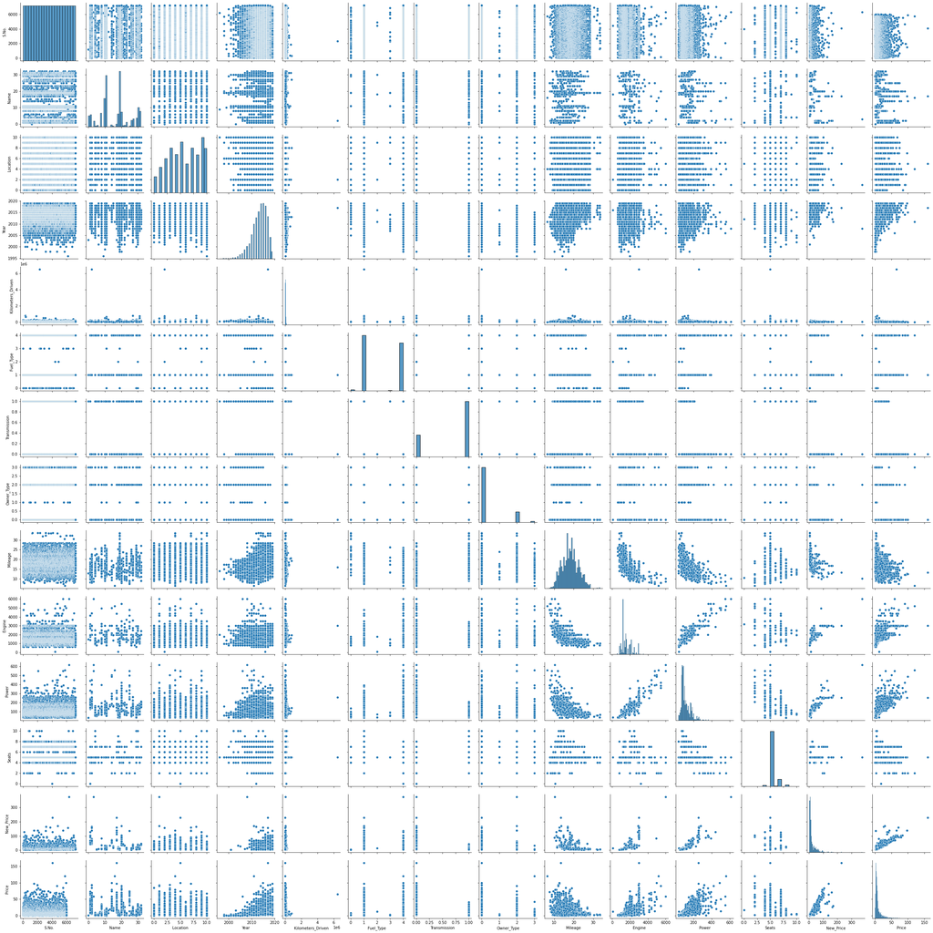

```python
sns.pairplot(car4udf2); #pair plot multiple pair wise bivariate distributions
```

The pair plot between the values in dataset show the overall distribution against each of the int columns. This give an overall view against the selected dataset values.

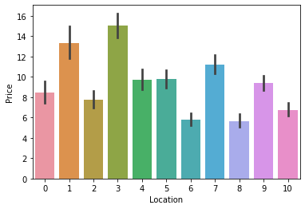

```python
sns.barplot(x='Location', y='Price', data=car4udf2) #Analysis with the target variable (Price)
```

Location and price do not have very strong correlation.

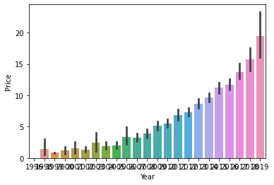

```python
sns.barplot(x='Year', y='Price', data=car4udf2) #Analysis with the target variable (Price)
```

There are many outliers. Newer the car the price is also high. There is expected positive correlation.

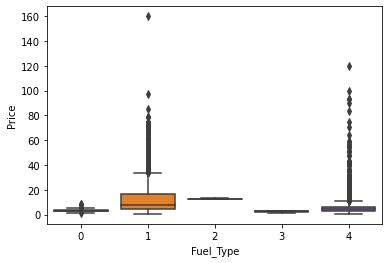

```python
sns.boxplot(x="Fuel_Type", y="Price", data=car4udf2); #Analysis with the target variable (Price)
```

Diesel and Petrol are most popular and more expensive. Strong correlation is missing.

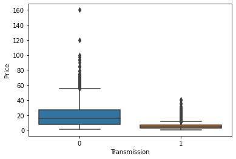

```python
sns.boxplot(x="Transmission", y="Price", data=car4udf2); ##Analysis with the target variable (Price)
```

Automatic transmission has more price. There are many outliers

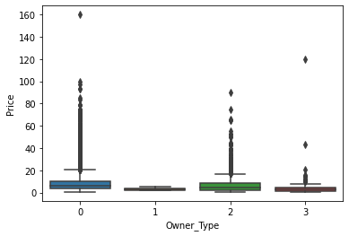

```python
sns.boxplot(x="Owner_Type", y="Price", data=car4udf2); ##Analysis with the target variable (Price)
```

Although First hand card is most sold cars but there is not very strong correlation between price and owner_type. There are many outliers.

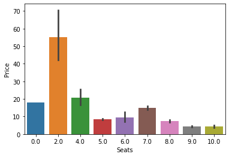

```python
sns.barplot(x='Seats', y='Price', data=car4udf2)
```

Two seater cars are mostly premium cars hence the price is very compared to others

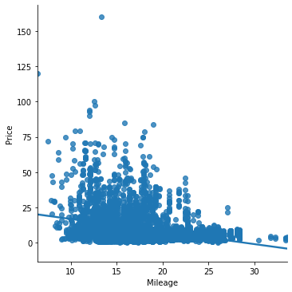

```python
sns.lmplot(x="Mileage", y="Price", data=car4udf2); #use of Implot
```

More powerful and expensive cars have less mileage hence there is a negative correlation between mileage and price for the dataset. In case analysis has to be done for normal cars the premium cars can be considered outliers are can be treated as separate assessment category.

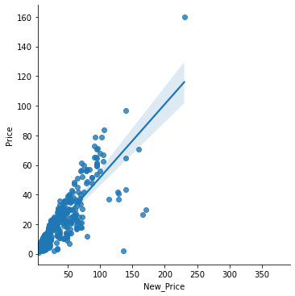

```python
sns.lmplot(x="New_Price", y="Price", data=car4udf2); #use of Implot
```

There is as strong positive correlation between new price and price

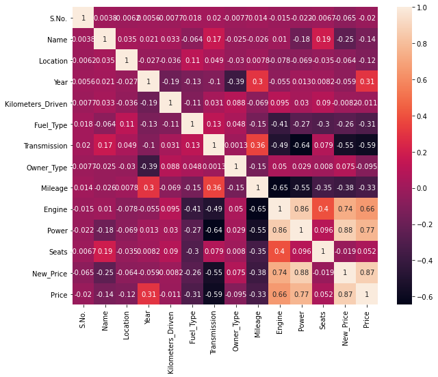

```python
plt.figure(figsize=(10,8))
sns.heatmap(car4udf2.corr(),annot=True)
plt.show()
```

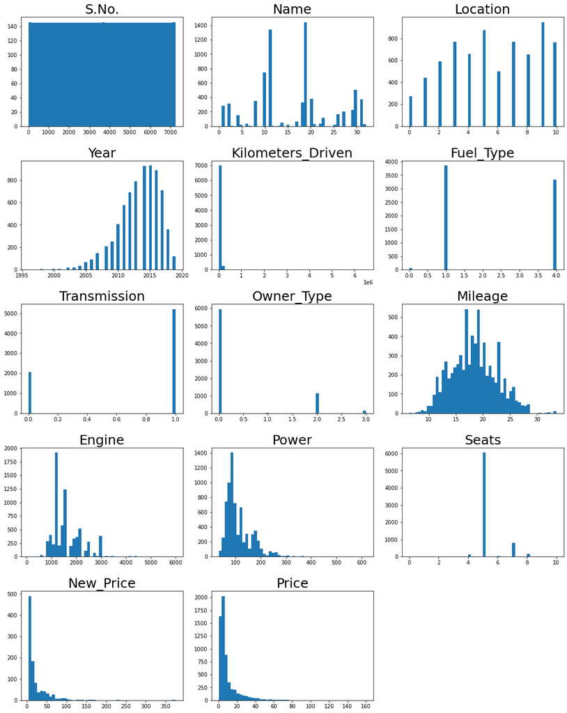

```python
# creating a list of non-tag columns
dist_cols = [
    item for item in car4udf2.select_dtypes(include=np.number).columns if "tag" not in item
]

# let's plot a histogram of all non-tag columns

plt.figure(figsize=(15, 45))

for i in range(len(dist_cols)):
    plt.subplot(12, 3, i + 1)
    plt.hist(car4udf2[dist_cols[i]], bins=50)
    # sns.histplot(data=df3, x=dist_cols[i], kde=True)  # you can comment the previous line and run this one to get distribution curves
    plt.tight_layout()
    plt.title(dist_cols[i], fontsize=25)

plt.show()
```

Droping the New Price despite strong correlation with Price as most of the values are not available

```python
car4udf2.drop(['New_Price'], axis=1, inplace=True) #new price dropped
car4udf2.drop(['S.No.'], axis=1, inplace=True) #new price dropped
```

```python
car4udf2.describe(include="all").T #describe after the change
```

|  | count | mean | std | min | 25% | 50% | 75% | max |
| --- | --- | --- | --- | --- | --- | --- | --- | --- |
| Name | 7253.00000 | 16.38701 | 8.59993 | 0.00000 | 10.00000 | 18.00000 | 20.00000 | 32.00000 |
| Location | 7253.00000 | 5.62236 | 2.96966 | 0.00000 | 3.00000 | 6.00000 | 8.00000 | 10.00000 |
| Year | 7253.00000 | 2013.36537 | 3.25442 | 1996.00000 | 2011.00000 | 2014.00000 | 2016.00000 | 2019.00000 |
| Kilometers_Driven | 7253.00000 | 58699.06315 | 84427.72058 | 171.00000 | 34000.00000 | 53416.00000 | 73000.00000 | 6500000.00000 |
| Fuel_Type | 7253.00000 | 2.37033 | 1.50460 | 0.00000 | 1.00000 | 1.00000 | 4.00000 | 4.00000 |
| Transmission | 7253.00000 | 0.71750 | 0.45025 | 0.00000 | 0.00000 | 1.00000 | 1.00000 | 1.00000 |
| Owner_Type | 7253.00000 | 0.37598 | 0.81591 | 0.00000 | 0.00000 | 0.00000 | 0.00000 | 3.00000 |
| Mileage | 7170.00000 | 18.34653 | 4.15791 | 6.40000 | 15.30000 | 18.20000 | 21.10000 | 33.54000 |
| Engine | 7207.00000 | 1616.57347 | 595.28514 | 72.00000 | 1198.00000 | 1493.00000 | 1968.00000 | 5998.00000 |
| Power | 7078.00000 | 112.76521 | 53.49355 | 34.20000 | 75.00000 | 94.00000 | 138.10000 | 616.00000 |
| Seats | 7200.00000 | 5.27972 | 0.81166 | 0.00000 | 5.00000 | 5.00000 | 5.00000 | 10.00000 |
| Price | 6019.00000 | 9.47947 | 11.18792 | 0.44000 | 3.50000 | 5.64000 | 9.95000 | 160.00000 |

```python
car4_mod = car4udf2.copy()
missingvaluecheck(car4_mod) #check for missing values
```

|  | Total | % of Missing Val |
| --- | --- | --- |
| Price | 1234 | 0.17014 |
| Power | 175 | 0.02413 |
| Mileage | 83 | 0.01144 |
| Seats | 53 | 0.00731 |
| Engine | 46 | 0.00634 |
| Owner_Type | 0 | 0.00000 |
| Transmission | 0 | 0.00000 |
| Fuel_Type | 0 | 0.00000 |
| Kilometers_Driven | 0 | 0.00000 |
| Year | 0 | 0.00000 |
| Location | 0 | 0.00000 |
| Name | 0 | 0.00000 |

```python
car4_mod['Power']=car4_mod['Power'].fillna(car4_mod['Power'].mode()[0]) #handle missing values
car4_mod['Engine']=car4_mod['Engine'].fillna(car4_mod['Engine'].mode()[0]) #handle missing values
car4_mod['Seats']=car4_mod['Seats'].fillna(car4_mod['Seats'].mode()[0]) #handle missing values
car4_mod['Mileage']=car4_mod['Mileage'].fillna(car4_mod['Mileage'].mode()[0]) #handle missing values
car4_mod['Price']=car4_mod['Price'].fillna(car4_mod['Price'].mode()[0]) #handle missing values
missingvaluecheck(car4_mod)
```

|  | Total | % of Missing Val |
| --- | --- | --- |
| Price | 0 | 0.00000 |
| Seats | 0 | 0.00000 |
| Power | 0 | 0.00000 |
| Engine | 0 | 0.00000 |
| Mileage | 0 | 0.00000 |
| Owner_Type | 0 | 0.00000 |
| Transmission | 0 | 0.00000 |
| Fuel_Type | 0 | 0.00000 |
| Kilometers_Driven | 0 | 0.00000 |
| Year | 0 | 0.00000 |
| Location | 0 | 0.00000 |
| Name | 0 | 0.00000 |

## Model building - Linear Regression

```python
car4lr = car4_mod.copy() #copy the dataframe
car4lr.info() #check
```

```
<class 'pandas.core.frame.DataFrame'>
RangeIndex: 7253 entries, 0 to 7252
Data columns (total 12 columns):
 #   Column             Non-Null Count  Dtype
---  ------             --------------  -----
 0   Name               7253 non-null   int8
 1   Location           7253 non-null   int8
 2   Year               7253 non-null   int64
 3   Kilometers_Driven  7253 non-null   int64
 4   Fuel_Type          7253 non-null   int8
 5   Transmission       7253 non-null   int8
 6   Owner_Type         7253 non-null   int8
 7   Mileage            7253 non-null   float64
 8   Engine             7253 non-null   float64
 9   Power              7253 non-null   float64
 10  Seats              7253 non-null   float64
 11  Price              7253 non-null   float64
dtypes: float64(5), int64(2), int8(5)
memory usage: 432.2 KB
```

```python
X = car4lr.drop("Price", axis=1)
y = car4lr["Price"]
```

### Split the data into train and test

```python
from sklearn.model_selection import train_test_split #Use sklearn

#Split random 70-30 for for training and testing
x_train, x_test, y_train, y_test = train_test_split(
    X, y, test_size=0.3, random_state=1
)
```

```python
print("Number of rows in train data =", x_train.shape[0]) #display shape
print("Number of rows in train data =", x_test.shape[0]) #display shape
```

```
Number of rows in train data = 5077
Number of rows in train data = 2176
```

### Fitting a linear model

```python
# intialize the model to be fit and fit the model on the train data
regression_model = LinearRegression()
regression_model.fit(x_train, y_train)
```

```
LinearRegression()
```

```python
#Calculate R-squared in traing set
print("The score (R-squared) on the training set is ",regression_model.score(x_train, y_train),)
```

```
The score (R-squared) on the training set is  0.5610200842229109
```

```python
#Calculate R-squared in traing set
print("The score (R-squared) on the test set is ", regression_model.score(x_test, y_test))
```

```
The score (R-squared) on the test set is  0.49862685246786087
```

```python
#Calculate Root Mean Square Error (RMSE) for the model
print("The Root Mean Square Error (RMSE) of the model for the test set is ",np.sqrt(mean_squared_error(y_test,
    regression_model.predict(x_test))),)
```

```
The Root Mean Square Error (RMSE) of the model for the test set is  7.727898775657976
```

```python
# let's check the coefficients and intercept of the model
coef_df = pd.DataFrame(
    np.append(regression_model.coef_, regression_model.intercept_),
    index=x_train.columns.tolist() + ["Intercept"],
    columns=["Coefficients"],
)
coef_df
```

|  | Coefficients |
| --- | --- |
| Name | -0.01873 |
| Location | -0.15359 |
| Year | 0.71809 |
| Kilometers_Driven | -0.00002 |
| Fuel_Type | -0.73222 |
| Transmission | -2.30234 |
| Owner_Type | 0.07903 |
| Mileage | -0.14436 |
| Engine | 0.00186 |
| Power | 0.08872 |
| Seats | -0.79175 |
| Intercept | -1437.69090 |

```python
# Adjusted R^2
def adj_r2(ind_vars, targets, predictions):
    r2 = r2_score(targets, predictions)
    n = ind_vars.shape[0]
    k = ind_vars.shape[1]
    return 1 - ((1 - r2) * (n - 1) / (n - k - 1))


# Model performance check
def model_perf(model, inp, out):

    y_pred = model.predict(inp)
    y_act = out.values

    return pd.DataFrame(
        {
            "RMSE": np.sqrt(mean_squared_error(y_act, y_pred)),
            "MAE": mean_absolute_error(y_act, y_pred),
            "R^2": r2_score(y_act, y_pred),
            "Adjusted R^2": adj_r2(inp, y_act, y_pred),
        },
        index=[0],
    )
```

```python
# Checking model performance on train set
print("Training Performance\n")
print(model_perf(regression_model, x_train, y_train))

# Checking model performance on test set
print("\n\nTest Performance\n")
print(model_perf(regression_model, x_test, y_test))
```

```
Training Performance

     RMSE     MAE     R^2  Adjusted R^2
0 6.70094 3.82221 0.56102       0.56007


Test Performance

     RMSE     MAE     R^2  Adjusted R^2
0 7.72790 3.79531 0.49863       0.49608
```